# PROSPER LOAN ANALYSIS

## BELOW VISUALISED GRAPH ARE NUMERIC ATTRIBUTES

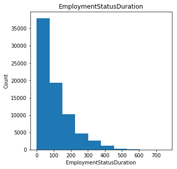

```python
plt.figure(figsize = [5, 5])
plt.hist(data = df_loan, x = 'EmploymentStatusDuration');
plt.xlabel('EmploymentStatusDuration');
plt.ylabel('Count');
plt.title("EmploymentStatusDuration");
```

observation **Here the graph is right skewed also the graph represents the peak in the 0-100 observations only**

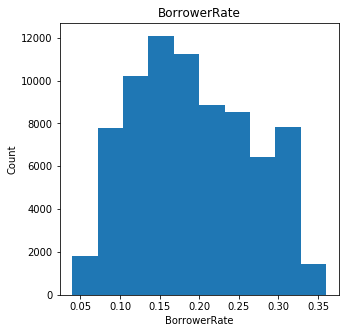

```python
plt.figure(figsize = [5, 5])
plt.hist(data = df_loan, x = 'BorrowerRate');
plt.xlabel('BorrowerRate');
plt.ylabel('Count');
plt.title("BorrowerRate");
```

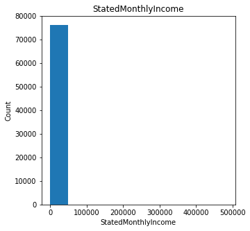

```python
plt.figure(figsize = [5, 5])
plt.hist(data = df_loan, x = 'StatedMonthlyIncome');
plt.xlabel('StatedMonthlyIncome');
plt.ylabel('Count');
plt.title("StatedMonthlyIncome");
```

obvervation **StateMonthlyIncome is in between 0 to 1 lakh this helps us in determining whether monthy income plays a role in deciding the a loan has to be given or not**

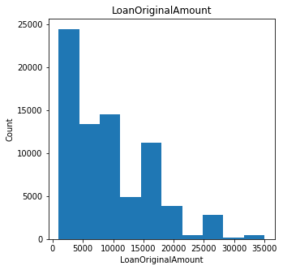

```python
plt.figure(figsize = [5, 5])
plt.hist(data = df_loan, x = 'LoanOriginalAmount');
plt.xlabel('LoanOriginalAmount');
plt.ylabel('Count');
plt.title("LoanOriginalAmount");
```

observation **LoanOriginalAmount is right skewed 5000 has the most loans there is decrease in count with increase in loan amount**

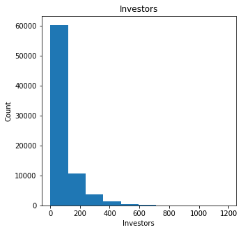

```python
plt.figure(figsize = [5, 5])
plt.hist(data = df_loan, x = 'Investors');
plt.xlabel('Investors');
plt.ylabel('Count');
plt.title("Investors");
```

observation **Invertors are almost null in 700 and above range the invertors are maximum in range of 0-200 ans also the graph is right skewed**

## Univariate Analysis

loans with AA category are really less

employment status of borrowers are Employed

BorrowerRate have a peak Around 0.15.

LoanOriginalAmount is right skewed

Invertors are almost null in 700 and above range